# ggplot for Time Series Data

Matthew Heino

2025-01-30

# Data Description

- Variable 1: **Date** - (dttm) holds the date in the following format: 2017-09-01 00:00:00
- Variable 2: **Battery** - (int) the number of battery incidents

# Data Wrangling

The data needed to be prepared before it could be processed. The steps are the following:

- Step 1: Read in the data from the rds file (“Crime3years.rds”).
- Step 2: View the contents of the data frame.
- Step 3: Select two years from the data set
- Step 4: Create the different parts of the date
- Step 5: Aggregate the hourly data into the weekly data
- Step 6: Aggregate the data into monthly data
- Step 7: Graph the data

Loading the appropriate packages will be necessary.

### Load and Install the Required Packages

The required packages for this assignment were:

- tidyverse
- zoo
- lubridate

```r
if(!require(tidyverse)) {install.packages('tidyverse')}; require(tidyverse)
if(!require(zoo)) {install.packages('zoo')}; require(zoo)
if(!require(lubridate)) {install.packages('lubridate')}; require(lubridate)

library(tidyverse)
library(zoo)
library(lubridate)
```

Set the Working Directory.

```r
setwd(dirname(rstudioapi::getSourceEditorContext()$path))
```

Read in the data from the RDS File (“Crime3years.rds”)

```r
crime_bat <- readRDS("Crime3years.rds")
```

### Step 2: View the Contents of the Data Frame

```r
glimpse(crime_bat)
```

```
## Rows: 26,304
## Columns: 2
## $ Date    <dttm> 2017-09-01 00:00:00, 2017-09-01 01:00:00, 2017-09-01 02:00:00…
## $ Battery <int> 0, 0, 0, 0, 0, 1, 2, 8, 2, 3, 4, 6, 9, 3, 7, 9, 7, 3, 6, 7, 3,…
```

### Step 3: Select Two Years from the Data Set

```r
two_year_crime <- crime_bat %>% filter(between(as_date(Date),
                                               as_date("2018-01-01"),
                                               as_date("2018-01-01") + 730))
```

### Step 4: Create the Different Parts of the Date

In this step the data will be decomposed into the parts that are needed to complete the assignment. New variables will be created. This will result in a new data frame that will contain this new variables. This is the same procedure that was carried out Module 10.

```r
two_year_crime_new <- two_year_crime %>%
  mutate(hour = hour(two_year_crime$Date),week= weekdays(two_year_crime$Date),
         month = month(two_year_crime$Date),year=year(two_year_crime$Date)) %>%
  mutate(weeknum= strftime(Date, format = '%V')) %>%
  mutate(monthnum= strftime(Date, format = '%m'))
```

### Step 5: Aggregate the Hourly Data into Weekly Data

The hourly data will be aggregated into the weekly data and then this will be stored in a data frame. This data frame will be used to to create the graphs in a the **Data Visualization** section of this document.

```r
two_year_crime_weekly <- two_year_crime_new %>%
  group_by(weeknum,year) %>%
  summarize(case_weekly=sum(Battery)) %>%
  mutate(yearweek=paste(year,weeknum, 1, sep=''))
```

Remove the 2020 dates from the data frame. They will not be used in the required graphs.

```r
two_year_crime_weekly <- two_year_crime_weekly[two_year_crime_weekly$year !=
                                                 2020, ]

two_year_crime_weekly <- arrange(two_year_crime_weekly,
                                 two_year_crime_weekly$year,
                                 two_year_crime_weekly$weeknum)
```

Add an additional variable to help in graphing the weekly data.

```r
two_year_crime_weekly <- two_year_crime_weekly %>%
  mutate(weeklydate = as.Date(yearweek,"%Y%W%w"))
```

### Step 6: Aggregate the Hourly Data Into Monthly Data

The hourly data will be aggregated into the monthly data and then this will be stored in a data frame. This data frame will be used to to create the graphs in a the Data Visualization section of this document.

```r
two_year_crime_monthly <- two_year_crime_new %>%
  mutate(hour = hour(two_year_crime_new$Date), week=weekdays(two_year_crime_new$Date),
         month = month(two_year_crime_new$Date), year=year(two_year_crime_new$Date)) %>%
  group_by(monthnum, year) %>%
  summarize(case_monthly=sum(Battery)) %>%
  mutate(yearmonth=paste(year,monthnum,sep='-')) %>%
  mutate(first=1) %>%
  mutate(yearandmonth = as.Date(format(as.Date(paste(year, monthnum, 1, sep="."),"%Y.%m.%d"),
                                       "%Y-%m-%d"))) %>%
  mutate(myDate=as.Date(format(as.Date(paste(1,monthnum,year,sep="."),"%d.%m.%Y"),"%Y-%m-%d")))
```

Remove the rows required by the assignment. Arrange the data in order and check the data to see the result is what is expected.

```r
two_year_crime_monthly <-
  two_year_crime_monthly[two_year_crime_monthly$year != 2020, ]

# order by the year then by month
two_year_crime_monthly <- arrange(two_year_crime_monthly,
                                  two_year_crime_monthly$year,
                                  two_year_crime_monthly$monthnum)
```

# Data Visualizations

The data visualization will make use of the ggplot library of functions for graphing. The graphs will use the **scale_x_datetime** and the **scale_x_date** to format the x-axis. The data visualizations that are required for the assignment are the following:

- Time series visualization of the hourly data
- Time series visualization of the weekly data
- Time series visualization of the monthly data
- A stacked time series visualization of the monthly using the years and months

### Graph the hourly data

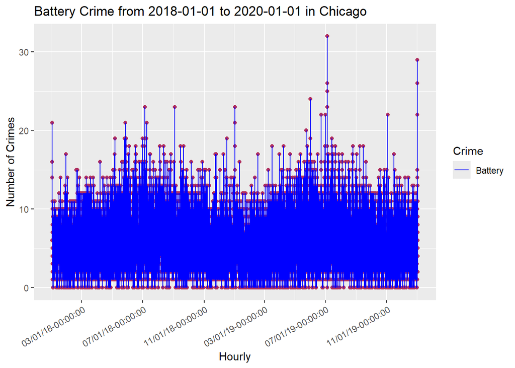

```r
two_year_crime %>% ggplot(aes(x = Date, y = Battery, lty="Battery")) +
  geom_point(col = "maroon") +
  geom_line(col = "blue") +
  scale_linetype('Crime') +
  scale_x_datetime(date_breaks= "4 months", date_labels = "%m/%d/%y-00:00:00") +
  theme(axis.text.x=element_text(angle=30, hjust=1)) +
  labs(title = "Battery Crime from 2018-01-01 to 2020-01-01 in Chicago",
       x = "Hourly", y = "Number of Crimes", shape='Battery')
```

### Graph the Weekly Data

[figure not shown]

```r
two_year_crime_weekly%>%
  ggplot(aes(x = weeklydate, y = case_weekly, group=1, color="blue",lty="Battery")) +
  geom_point(col = "maroon") +
  geom_line(col = "blue") +
  scale_linetype('Crime') +
  labs(title = "Battery Crime from 2017-09-01 to 2019-08-31 in Chicago",
       x = "Year-Week", y = "Number of Crimes")+
  scale_x_date(date_labels = "%Y/%U")
```

### Graph the Monthly Data

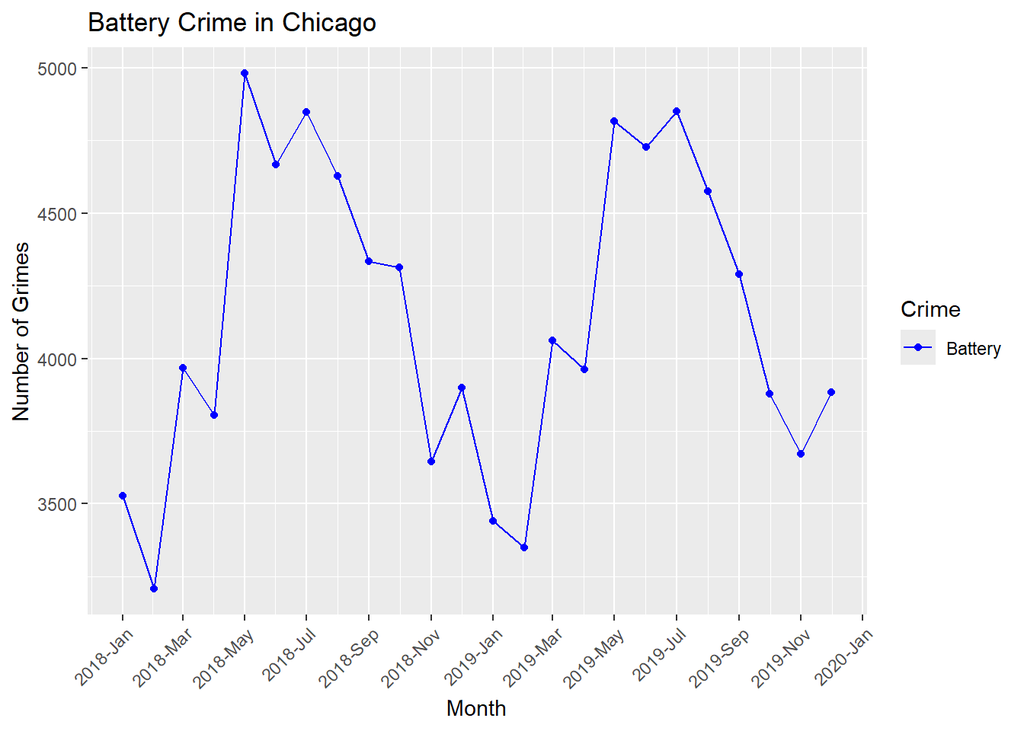

```r
ggplot(two_year_crime_monthly, aes(x=yearandmonth, y=case_monthly, color="red")) +
  geom_point() +
  geom_line() +
  xlab("Month") +
  ylab("Number of Grimes")+
  ggtitle("Battery Crime in Chicago") +
  labs(color="Crime") +
  scale_color_manual(labels = c("Battery"), values = c("blue")) +
  scale_x_date(date_breaks = "2 month", date_labels = "%Y-%b")+
  theme(axis.text.x=element_text(angle=45, hjust=1))
```

### A Stacked Time Series Visualization of the Monthly Data Using the Years and Months

An additional variable was created to allow the two years to be graphed in a stacked manner. If this was not done the graph lines for each year will be displayed in a series manner and not stacked.

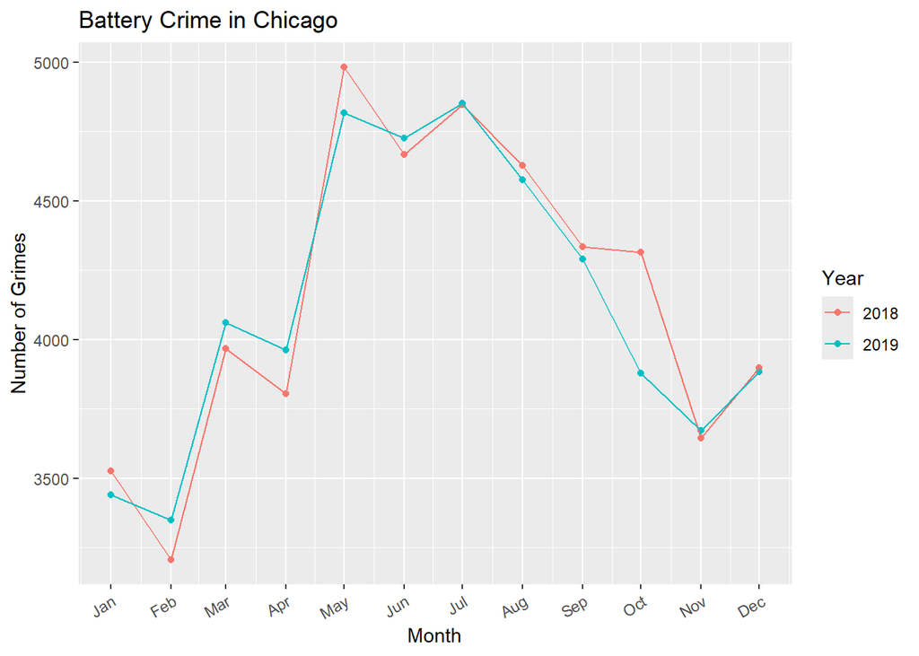

```r
two_years <- two_year_crime_monthly %>%
  mutate(monthDay= as.Date(paste(first, monthnum, sep="."), "%d.%m"))

ggplot(two_years, aes(x= monthDay, y=case_monthly, color=as.factor(year))) +
  geom_point() +
  geom_line() +
  xlab("Month") +
  ylab("Number of Grimes")+
  ggtitle("Battery Crime in Chicago") +
  scale_x_date(date_breaks = "1 month", date_labels = "%b")+
  theme(axis.text.x=element_text(angle=30, hjust=1)) +
  guides(color=guide_legend(title = "Year"))
```